# Distance weighted interpolation with R

Guillaume Blanchet & Steve Vissault

November 19th, 2019

# Inverse Distance weighting with R

## Prepare the data for analysis

First, we download the spatial data:

1. [The GeoDatabase containing all shapefiles for the study area](https://github.com/SteveViss/PR-GSFE01/raw/master/data/raw/hamilton_harbor.gdb.zip)
2. [The CABIN data for Hamilton Harbour](https://github.com/SteveViss/PR-GSFE01/raw/master/data/post_process/hamilton_habitat.rds)

Import the data in R.

```r
library(sf)
# The RDS file is an R object and can be read with the following command:
hamilton_habitat_desc <- readRDS("../data/post_process/hamilton_habitat.rds")
lake <- st_read("../data/raw/hamilton_harbor.gdb", layer="waterbody_2")
# Making sure both are on the same CRS
st_crs(lake) == st_crs(hamilton_habitat_desc)
```

```
## [1] FALSE
```

```r
hamilton_habitat_desc <- st_transform(hamilton_habitat_desc, st_crs(lake))
```

Filter the variable total phosphorus (ppm). Because, the data contains replicates (several years and samples), we want to average all measurements of total phosphorus by site.

```r
library(dplyr)

hamilton_avg_tp <- hamilton_habitat_desc %>%
  filter(Variable == "TP") %>%
  group_by(Site.Site) %>%
  summarise(avg_tp=mean(Value.Valeur))
```

We perform a visual check of the mean variable.

```r
library(mapview)
mapview(hamilton_avg_tp, zcol='avg_tp', cex = 'avg_tp' )
```

[interactive chart not shown]

We need to transform the `sf` spatial object to `sp`, because the `gstat` package doesn’t support `sf` class.

```r
hml_avg_tp <- as(hamilton_avg_tp, "Spatial")
lake <- as(lake, "Spatial")
```

The data is now ready for analysis.

## Fit the Inverse Distance Weight (IDW)

We need to load the needed libraries for the analysis.

```r
library(raster)
library(gstat)
```

We fit the IDW model on the data. We can easily play with the smoothing paramater `c` with `set = list(idp = 5)` in the `gstat` function.

```r
gs <- gstat(formula=avg_tp~1, locations=hml_avg_tp)
gs_5 <- gstat(formula=avg_tp~1, locations=hml_avg_tp, set = list(idp = 5))
```

### Build the predictions map

Then, when the model is fitted, we want to make a predictions map. We create the reference grid for model projection (using the extent of the `lake`).

```r
r_ref <- raster(lake,res=100)
```

And we project the model on the reference grid

```r
idw <- interpolate(r_ref, gs)
```

```
## [inverse distance weighted interpolation]
```

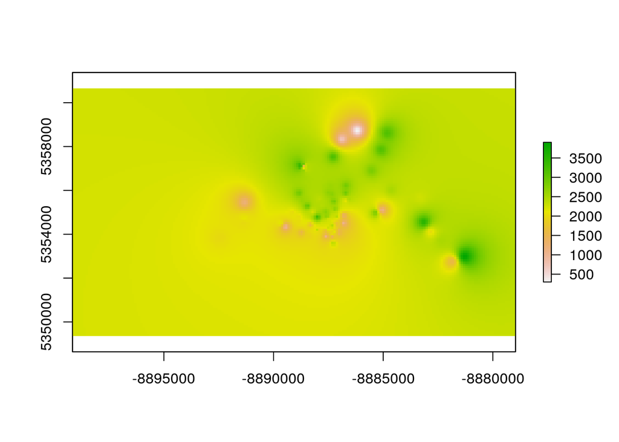

```r
plot(idw)
```

As you can see, the model estimates the values for the entire extent of the reference grid. We can mask those values using the following command:

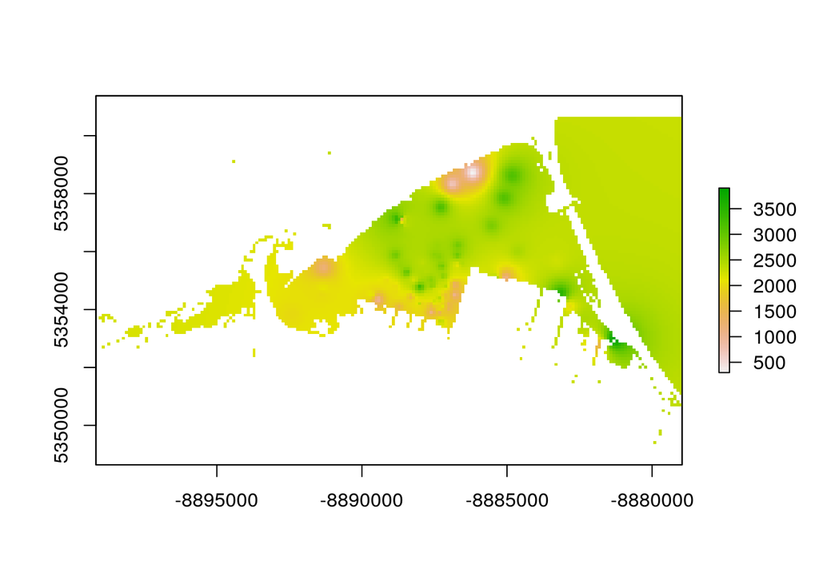

```r
idw_mask <- mask(idw, lake)
plot(idw_mask)
```

We can then compare with the map predictions for `c = 5`

```r
idw5 <- interpolate(r_ref, gs_5)
```

```
## [inverse distance weighted interpolation]
```

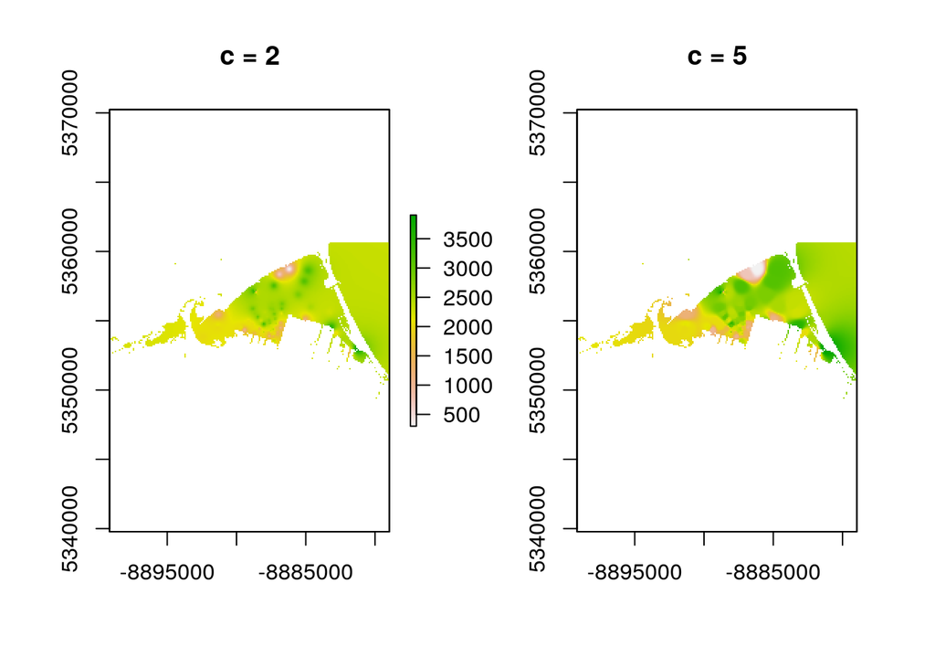

```r
idw5_mask <- mask(idw5, lake)

par(mfrow=c(1,2))
plot(idw_mask, main = "c = 2")
plot(idw5_mask, main = "c = 5", legend = FALSE)
```

### Exercice

1. Construct an inverse distance weighting map using another variable
2. Construct an inverse distance weighting map using your own data

## Evaluate model quality

The choice of the power function parameter (through `idp`) might be subjective. Let’s perform quality evaluation through with Leave-one-out validation routine (LOOCV) with $c = 2$.

```r
IDW_out <- vector(length = length(hml_avg_tp))
for (i in 1:length(hml_avg_tp)) {
  IDW_out[i] <- idw(avg_tp ~ 1, hml_avg_tp[-i,], hml_avg_tp[i,], idp = 2, debug.level = 0)$var1.pred
}
```

We then can assess the model quality by comparing the observed versus the predicted data

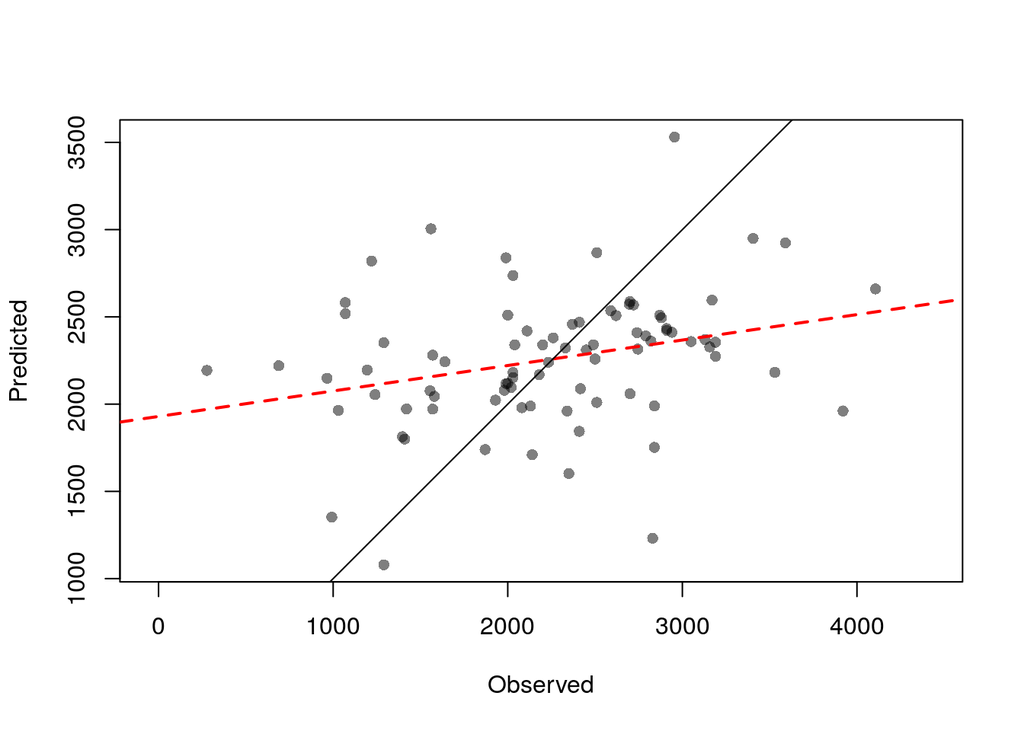

```r
plot(IDW_out ~ hml_avg_tp$avg_tp, asp=1, xlab="Observed", ylab="Predicted", pch=16,
      col=rgb(0,0,0,0.5))
abline(lm(IDW_out ~ hml_avg_tp$avg_tp), col="red", lw=2,lty=2)
abline(0,1)
```

### Model quality statistics

#### Quick reminder of the statistics to use

Using the vector `IDW_out`, we can compute the mean of squared prediction error (MSPE) for the IDW model (with $c = 2$)

```r
mean((hml_avg_tp$avg_tp - IDW_out)^2)
```

```
## [1] 542716.3
```

### Finding the optimum $c$ value

#### Define the cost function

`optim()` is general-purpose optimization function. `optim()` will cover the parameter space (here $c$) in order to minimize the mean squared prediction error (MSPE). Once the minimum MSPE found, `optim` returns the best corresponding $c$ value. For this purpose, you need to provide a cost function to `optim`. This function `cost_fun` takes the $c$ parameter as an argument and compute the MSPE with the Leave-one-out validation routine (LOOCV).

```r
cost_fun <- function(const){
  IDW_out <- vector(length = length(hml_avg_tp))
  for (i in 1:length(hml_avg_tp)) {
    IDW_out[i] <- idw(avg_tp ~ 1, hml_avg_tp[-i,], hml_avg_tp[i,], idp = const, debug.level = 0)$var1.pred
  }
  # Return the MSPE for the c value
  return(mean((hml_avg_tp$avg_tp - IDW_out)^2))
}

# Set the initial c parameter
init_c <- 2
# Lauch optim function
optim(init_c, cost_fun, method = "Brent", lower = 1, upper = 3)
```

```
## $par
## [1] 1.179947
##
## $value
## [1] 527253.7
##
## $counts
## function gradient
##       NA       NA
##
## $convergence
## [1] 0
##
## $message
## NULL
```

### $K$-fold cross-validation

- **Step 1:** Randomly split the data into $K$ roughly equal-size group (or components or folds)

Declaring the number of groups (`nfold`), and attach each points to a specific group (`k`).

```r
nfolds <- 5
k <- sample(1:nfolds,length(hml_avg_tp), replace = TRUE)
k
```

```
##  [1] 1 4 1 4 4 5 1 5 2 1 3 4 3 1 3 1 1 1 2 1 5 4 3 5 2 1 3 3 3 1 2 2 5 1 2
## [36] 1 3 3 3 5 2 5 2 1 3 5 5 1 1 3 1 5 4 3 2 1 2 1 3 2 2 3 1 2 3 2 2 5 5 4
## [71] 3 1 5 1 4 4 3 5 5 2 3 2 1
```

```r
sf_hml <- st_as_sf(hml_avg_tp)
sf_hml$group <- k
mapview(sf_hml, zcol='group')
```

[interactive chart not shown]

- **Step 2:** Hold out one group (the $k^\text{th}$ group) and *train* the model on the remaining data. Usually, using 5 or 10 groups works well. The resulting model can be defined as $\widehat{Z}^{(-k)}_i$ for $i = 1, \dots, m_k$ where $m_k$ is the number of samples in the $k^\text{th}$ group.
- **Step 3:** Use a metric to evaluate the quality of the model (MSPE here)
- **Step 4:** Repeat steps 2 and 3 by holding out another group until all groups have been considered.
- **Step 5:** Evaluate the quality of the cross valiation using a $K$-fold cross-validation score

$$\text{CV}_{(K)} = \frac{1}{K} \sum_{k=1}^K \text{MSPE}_k$$

The cross-validation score is particularly useful if there is an interest in comparing different model formulation.

#### Step 2 to 5

```r
# Declare c parameter
const <- 2

# vector storing the MSPE value pour each fold
vec_MSPE <- rep(NA, nfolds)

# Looping over groups
for (i in 1:nfolds) {
  # Create training and validation set
  valid <- hml_avg_tp[k==i,]
  train <- hml_avg_tp[k!=i,]

  # Perform the IDW model on the training set
  m <- gstat(formula=avg_tp~1, locations=train, set=list(idp = const))
  preds <- predict(m, newdata=valid, debug = 0)$var1.pred

  # Assign the value to the MSPE vector
  vec_MSPE[i] <- mean((preds - valid$avg_tp)^2)
}

# Compute mean MSPE
cv_k <- mean(vec_MSPE)
```

### Exercice

1. Find the best value of $c$ using K-fold cross validation by changing the value of $c$ by increments of 0.1 Between $c$ values of 1, and 3.
2. How different is the “best” cross-validation value compared to the one obtained using `optim`. Why do you think this is different.

## Weighted Gaussian kernel

```r
# install.packages("spatialEco")
library("spatialEco")

# Include some data into the raster (if you do not it will not work !)
r_ref[1:length(r_ref)]<- 0

# Weighted gaussian kernel
wgk <- sp.kde(x= hml_avg_tp,
              y = hml_avg_tp$avg_tp,
              bw = 1000,
              newdata = r_ref,
              standardize = TRUE,
              scale.factor = 10000)
```

```
##
##  calculating weighted kde
```

```r
# Clean results for projection
wgk_mask <- mask(wgk, lake)

# Draw map
mapview(wgk_mask)
```

[interactive chart not shown]

### Exercice

Use a K-fold cross-validation to choose the best bandwitch value. Decide on - The increment to use for the bandwitch - The number of folds ($K$) to use in the cross-validation

By making these choices, you make a tradeoff between computation time and parameter estimation quality.